# ESE 417 Homework 1

Problem 1, Problem 3, Problem 5(c) are completed using python.  
Problem 2, Problem 4, Problem 5(a)(b) are written by hand.

#### Problem 1

(Use Python numpy package to finish this)  
Consider the following two real vectors: $𝒙=[−2.4, 1.5, 0.0, 3.2]^𝑇$ 𝑎𝑛𝑑 $𝒚=[1.3, 4.2, 3.0, −2.5]^𝑇$  
a) Find the 1-norm, 2-norm, 3-norm and infinity-norm of 𝒙, then sort them in a descending order.  
b) Find the distance between 𝒙 𝑎𝑛𝑑 𝒚, 𝑑(𝒙,𝒚)=‖𝒙−𝒚‖, using 1-norm,2-norm, and infinity-norm, then sort them in an ascending order.

```python
# a)

import numpy as np

# Define the two vectors
x = np.array([-2.4, 1.5, 0.0, 3.2])
y = np.array([1.3, 4.2, 3.0, -2.5])

print("x = ", x)
print("y = ", y)

# Calculate norms of x
norm_1_x = np.linalg.norm(x, ord=1)
norm_2_x = np.linalg.norm(x, ord=2)
norm_3_x = np.linalg.norm(x, ord=3)
norm_inf_x = np.linalg.norm(x, ord=np.inf)

print("Norms of x:")
print("L1 norm: ", norm_1_x)
print("L2 norm: ", norm_2_x)
print("L3 norm: ", norm_3_x)
print("L_inf norm: ", norm_inf_x)

# Sort norms of x in descending order
norms_x = np.array([norm_1_x, norm_2_x, norm_3_x, norm_inf_x])
norms_x_sorted = np.sort(norms_x)[::-1]
print("Sorted norms of x: ", norms_x_sorted)
```

```
x =  [-2.4  1.5  0.   3.2]
y =  [ 1.3  4.2  3.  -2.5]
Norms of x:
L1 norm:  7.1
L2 norm:  4.272001872658765
L3 norm:  3.683220833338153
L_inf norm:  3.2
Sorted norms of x:  [7.1        4.27200187 3.68322083 3.2       ]
```

```python
# b)

# Cauculate the distance between x and y in L1, L2 and L_inf norms
dist_1 = np.linalg.norm(x - y, ord=1)
dist_2 = np.linalg.norm(x - y, ord=2)
dist_inf = np.linalg.norm(x - y, ord=np.inf)

print("Distance between x and y:")
print("L1 distance: ", dist_1)
print("L2 distance: ", dist_2)
print("L_inf distance: ", dist_inf)

# Sort distances in ascending order
dists = np.array([dist_1, dist_2, dist_inf])
dists_sorted = np.sort(dists)
print("Sorted distances: ", dists_sorted)
```

```
Distance between x and y:
L1 distance:  15.100000000000001
L2 distance:  7.903796556086196
L_inf distance:  5.7
Sorted distances:  [ 5.7         7.90379656 15.1       ]
```

#### Problem 3

(use Numpy package in this problem)
Consider the following matrix: $$ B= \begin{bmatrix} 2 & 2 & 4 \\ 1 & 4 & 7 \\ 2 & 5 & 4 \end{bmatrix} $$ Find the eigenvalues and corresponding eigenvectors of matrix 𝑩 and then find the eigendecomposition of matrix 𝑩. Verify that B=𝑸𝜦𝑸-1

```python
import numpy as np

# Define the matrix B
B = np.array([[2, 2, 4],
              [1, 4, 7],
              [2, 5, 4]])

print("Matrix B:")
print(B)

# Calculate eigenvalues and eigenvectors of B
eigenvalues, eigenvectors = np.linalg.eig(B)

print("Eigenvalues of B:")
print(eigenvalues)
print("Eigenvectors of B:")
print(eigenvectors)
```

```
Matrix B:
[[2 2 4]
 [1 4 7]
 [2 5 4]]
Eigenvalues of B:
[10.93777843  1.25234419 -2.19012261]
Eigenvectors of B:
[[-0.42228933 -0.92515036 -0.29500861]
 [-0.67326244  0.37923364 -0.69446846]
 [-0.6069509  -0.01669331  0.65626479]]
```

```python
# Find the eigndecomposition of B
Q = eigenvectors
Lambda = np.diag(eigenvalues)
Q_inv = np.linalg.inv(Q)

print("Eigendecomposition of B:")
print("Q:")
print(Q)
print("Lambda:")
print(Lambda)
print("Q_inv:")
print(Q_inv)
```

```
Eigendecomposition of B:
Q:
[[-0.42228933 -0.92515036 -0.29500861]
 [-0.67326244  0.37923364 -0.69446846]
 [-0.6069509  -0.01669331  0.65626479]]
Lambda:
[[10.93777843  0.          0.        ]
 [ 0.          1.25234419  0.        ]
 [ 0.          0.         -2.19012261]]
Q_inv:
[[-0.24458613 -0.63090205 -0.77757728]
 [-0.88991249  0.47022663  0.09756081]
 [-0.24884369 -0.57153292  0.80710925]]
```

```python
# Verify the equation B = Q * Lambda * Q_inv
B_reconstructed = Q @ Lambda @ Q_inv

print("Reconstructed matrix B:")
print(B_reconstructed)

# Find B and B_reconstructed are equal
print("Are B and B_reconstructed equal? " + str(np.allclose(B, B_reconstructed)))
```

```
Reconstructed matrix B:
[[2. 2. 4.]
 [1. 4. 7.]
 [2. 5. 4.]]
Are B and B_reconstructed equal? True
```

#### Problem 5

Consider the following objective function: $f(x, y) = x^2 + 2y^2 - 2xy$  
a) Compute the Hessian matrix H of function f, and find the definiteness of matrix H.  
b) Use calculus method to find the minimum value of 𝑓(𝑥,𝑦)  
c) Use Python to implement the gradient descent search method to find the global minimum value of function f, suppose the initial values of [x, y] are [1,1]. Show the convergence curve of 𝑥 𝑎𝑛𝑑 𝑦 with learning rate: 0.1, 0.01, and 0.001. (Don’t use sk-learn package)

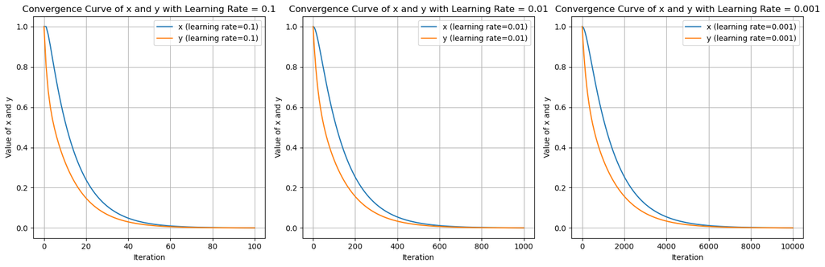

```python
import numpy as np
import matplotlib.pyplot as plt

# Function f(x, y)
def f(x, y):
    return x**2 + 2*y**2 - 2*x*y
# Gradient of f(x, y)
def grad_f(x, y):
    df_dx = 2*x - 2*y
    df_dy = 4*y - 2*x
    return np.array([df_dx, df_dy])

# Gradient descent implementation returning x and y values
def gradient_descent(initial_values, learning_rate, num_iterations):
    # Initialize lists to store x and y values
    x_vals = [initial_values[0]]
    y_vals = [initial_values[1]]
    for _ in range(num_iterations):
        # Calculate gradient at current point
        grad = grad_f(x_vals[-1], y_vals[-1])
        # Update x and y values
        new_x = x_vals[-1] - learning_rate * grad[0]
        new_y = y_vals[-1] - learning_rate * grad[1]
        # Append new x and y values to the lists
        x_vals.append(new_x)
        y_vals.append(new_y)
    return np.array(x_vals), np.array(y_vals)

# Initial values for (x, y)
initial_values = [1, 1]

# Learning rates and number of iterations
learning_rates = [0.1, 0.01, 0.001]
num_iterations_list = [100, 1000, 10000]

# Plot convergence for different learning rates
fig, axes = plt.subplots(1, 3, figsize=(15, 5))
for i, (lr, num_iterations) in enumerate(zip(learning_rates, num_iterations_list)):
    # Run gradient descent and store x and y values
    x_vals, y_vals = gradient_descent(initial_values, lr, num_iterations)
    axes[i].plot(x_vals, label=f'x (learning rate={lr})')
    axes[i].plot(y_vals, label=f'y (learning rate={lr})')
    axes[i].set_title(f'Convergence Curve of x and y with Learning Rate = {lr}')
    axes[i].set_xlabel('Iteration')
    axes[i].set_ylabel('Value of x and y')
    axes[i].legend(loc='upper right')
    axes[i].grid(True)

plt.tight_layout()
plt.show()
```